# [Chapter 9] Predicting sale price in Ames using LAD and LS

[DSLC stages]: Analysis

The following code sets up the libraries and creates cleaned and pre-processed training, validation and test data that we will use in this document.

```r
# loading libraries
library(tidyverse)
library(janitor)
library(L1pack)
library(lubridate)
library(yardstick)
library(scales)
library(patchwork)
# cleaning and pre-processing the Ames data
source("functions/prepareAmesData.R")
# list all objects (and custom functions) that exist in our environment
ls()
```

```
 [1] "ames"                    "ames_orig"
 [3] "ames_test"               "ames_test_clean"
 [5] "ames_test_preprocessed"  "ames_train"
 [7] "ames_train_clean"        "ames_train_preprocessed"
 [9] "ames_val"                "ames_val_clean"
[11] "ames_val_preprocessed"   "cleanAmesData"
[13] "preProcessAmesData"      "split_date"
[15] "train_neighborhoods"
```

## 1 Single predictor fits

### 1.1 LAD fit to the sample of 10 houses

Let’s first demonstrate generating a LAD fit for the sample of 10 houses.

First let’s create the sample of 10 houses that we used in the book.

```r
set.seed(589119)
sample_ames <- ames_orig |>
  filter(PID %in% ames_train_clean$pid) |>
  sample_n(10)
# create a clean version of the preview dataset
sample_ames_clean <- ames_train_clean |>
  filter(pid %in% sample_ames$PID) |>
  select(sale_price, gr_liv_area)
```

Let’s plot the living area against sale price using a scatterplot.

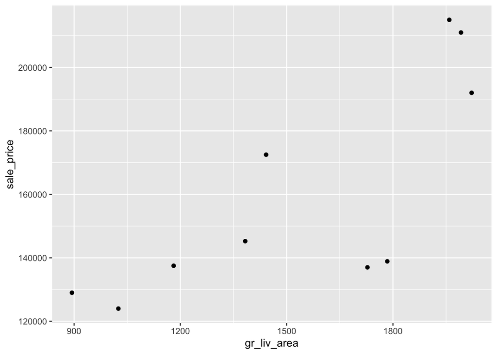

```r
sample_ames_clean |>
  ggplot() +
  geom_point(aes(x = gr_liv_area, y = sale_price))
```

Next, we can fit a LAD line as follows:

```r
lad_sample <- lad(sale_price ~ gr_liv_area,
                  sample_ames_clean,
                  method = "EM")
lad_sample
```

```
Call:
lad(formula = sale_price ~ gr_liv_area, data = sample_ames_clean,
    method = "EM")
Converged in 14 iterations

Coefficients:
(Intercept) gr_liv_area
 60966.6815     64.8038

Degrees of freedom: 10 total; 8 residual
Scale estimate: 22426.6
```

Note the syntax `y \sim x` means predict `y` using `x` as a predictor variable. The variable on the left is the response and the variable on the right is the predictive feature.

We can plot our LAD fitted line on our scatterplot:

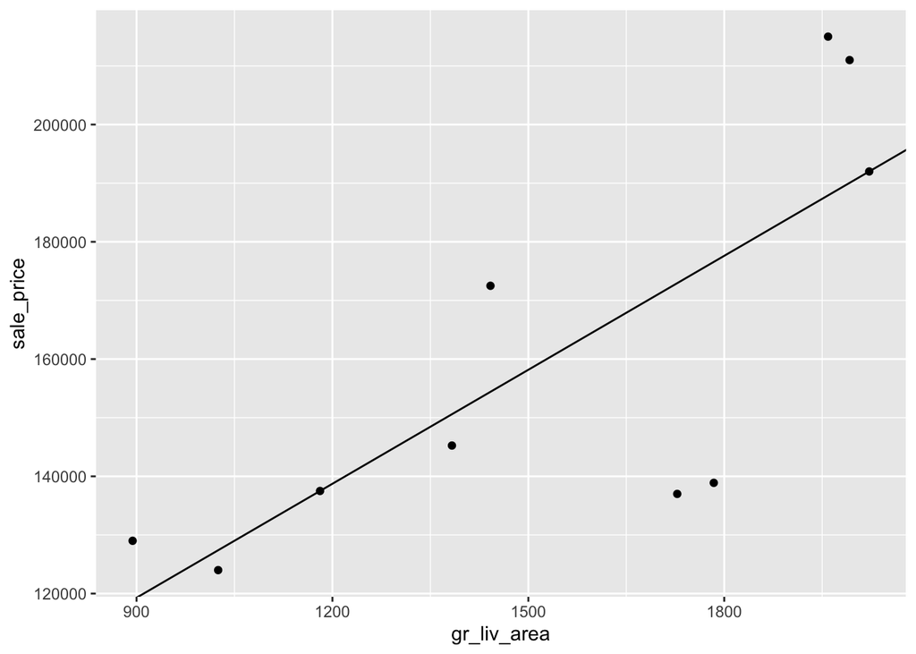

```r
sample_ames_clean |>
  ggplot() +
  geom_point(aes(x = gr_liv_area, y = sale_price)) +
  geom_abline(intercept = lad_sample$coefficients[1],
              slope = lad_sample$coefficients[2])
```

And we can predict the price of a 2000$ft^2$ house as follows (note that we rounded each coefficient to the nearest integer in the book, so the prediction is slightly different):

```r
predict(lad_sample, tibble(gr_liv_area = 2000))
```

```
       1
190574.3
```

### 1.2 LS fit to the sample of 10 houses

To apply least squares to the 10 training data houses, we use the `lm()` function.

We can fit a LS line as follows:

```r
ls_sample <- lm(sale_price ~ gr_liv_area,
                  sample_ames_clean)
ls_sample
```

```
Call:
lm(formula = sale_price ~ gr_liv_area, data = sample_ames_clean)

Coefficients:
(Intercept)  gr_liv_area
   61190.18        64.26
```

We can similarly plot our LS fitted line on our scatterplot on top of the LAD line (the two lines are very similar):

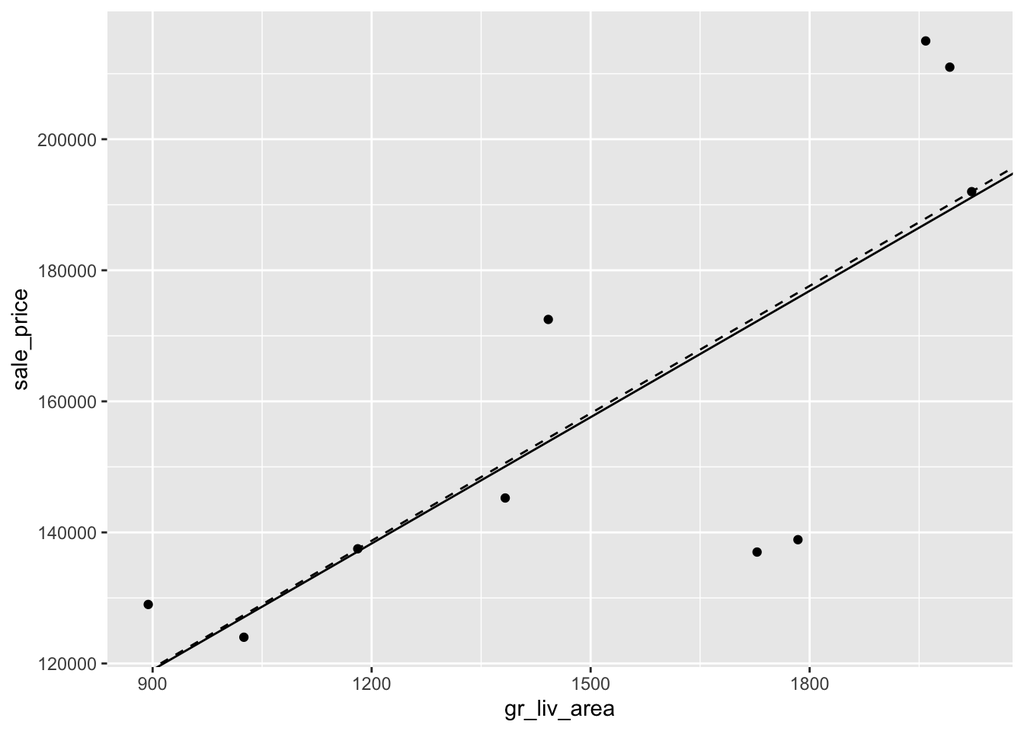

```r
sample_ames_clean |>
  ggplot() +
  geom_point(aes(x = gr_liv_area, y = sale_price)) +
  geom_abline(intercept = lad_sample$coefficients[1],
              slope = lad_sample$coefficients[2], linetype = "dashed") +
  geom_abline(intercept = ls_sample$coefficients[1],
              slope = ls_sample$coefficients[2])
```

And we can predict the price of a 2000$ft^2$ house as follows (note that we rounded each coefficient to the nearest integer in the book, so the prediction is slightly different):

```r
predict(ls_sample, tibble(gr_liv_area = 2000))
```

```
       1
189708.7
```

### 1.3 LS and LAD fit to the full training set (single predictor)

```r
lad_area <- lad(sale_price ~ gr_liv_area,
                ames_train_preprocessed,
                method = "EM")
lad_area
```

```
Call:
lad(formula = sale_price ~ gr_liv_area, data = ames_train_preprocessed,
    method = "EM")
Converged in 39 iterations

Coefficients:
(Intercept) gr_liv_area
 29669.0088     97.0302

Degrees of freedom: 1126 total; 1124 residual
Scale estimate: 43357.05
```

```r
ls_area <- lm(sale_price ~ gr_liv_area,
                ames_train_preprocessed)
ls_area
```

```
Call:
lm(formula = sale_price ~ gr_liv_area, data = ames_train_preprocessed)

Coefficients:
(Intercept)  gr_liv_area
    13407.5        109.4
```

And we can plot both lines on a scatterplot:

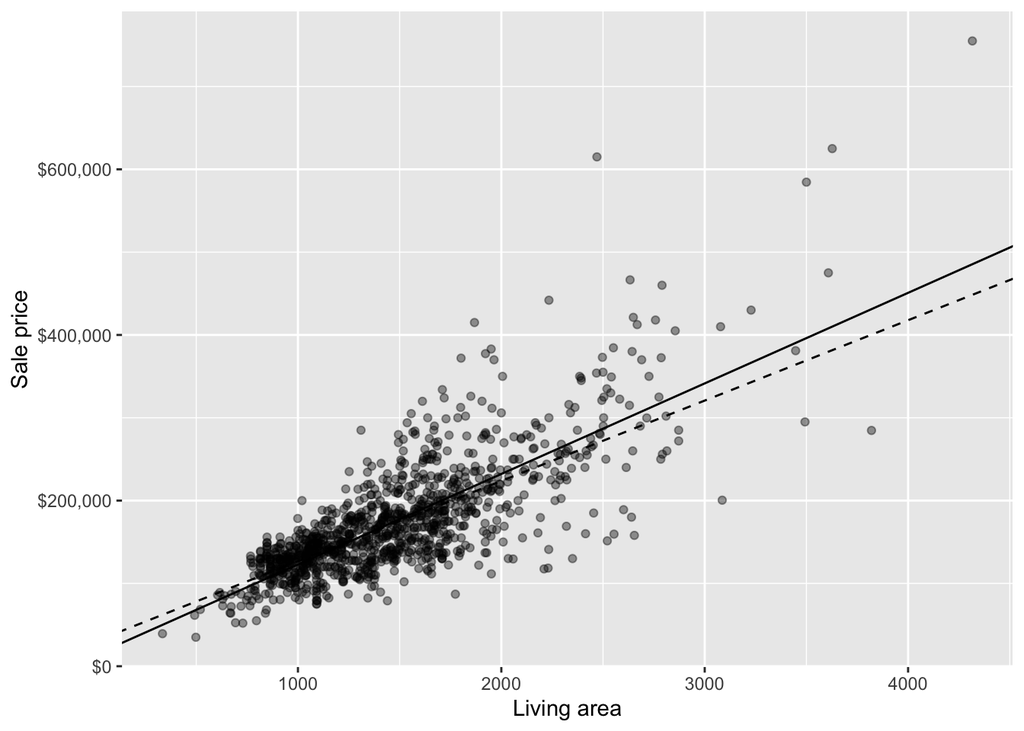

```r
ames_train_preprocessed |>
  ggplot(aes(x = gr_liv_area, y = sale_price)) +
  geom_point(alpha = 0.4) +
  geom_abline(intercept = ls_area$coefficients[1],
              slope = ls_area$coefficient[2]) +
  geom_abline(intercept = lad_area$coefficients[1],
              slope = lad_area$coefficient[2],
              linetype = "dashed")  +
  scale_y_continuous("Sale price",
                     labels = dollar_format()) +
  scale_x_continuous("Living area")
```

### 1.4 Training performance

Below we create a tibble containing the observed and predicted sale price for each training set house.

```r
pred_train_df <- tibble(true = ames_train_preprocessed$sale_price,
                      ls_pred = predict(ls_area, ames_train_preprocessed),
                      lad_pred = predict(lad_area, ames_train_preprocessed))
# look at the first 6 rows
head(pred_train_df)
```

```
# A tibble: 6 × 3
    true ls_pred lad_pred
   <int>   <dbl>    <dbl>
1 176500 168069.  166870.
2 237500 244962.  235082.
3 206900 244415.  234597.
4 187500 188851.  185305.
5 195500 188851.  185305.
6 192000 192569.  188604.
```

Then let’s pivot this tibble to a longer form so that we can simultaneously apply (using `group_by()` and `summarise()`) the rMSE, MAE, MAD, correlation, and $R^2$ evaluations to each algorithm (the `x_vec()` functions are from the yardstick R package, but there is no yardstick function for computing the correlation and MAD, so we compute these “manually”).

```r
pred_train_df |>
  pivot_longer(c("ls_pred", "lad_pred"),
               names_to = "algorithm",
               values_to = "pred") |>
  group_by(algorithm) |>
  summarise(rmse = rmse_vec(truth = true, estimate = pred),
            mae = mae_vec(truth = true, estimate = pred),
            mad = median(abs(true - pred)),
            cor = cor(true, pred),
            rsq = rsq_vec(truth = true, estimate = pred))
```

```
# A tibble: 2 × 6
  algorithm   rmse    mae    mad   cor   rsq
  <chr>      <dbl>  <dbl>  <dbl> <dbl> <dbl>
1 lad_pred  44952. 30658. 21533. 0.775 0.600
2 ls_pred   44492. 31077. 22420. 0.775 0.600
```

Across all metrics, the two algorithms are fairly similar, but, unsurprisingly, the LS algorithm looks better when evaluating using the rMSE, whereas the LAD algorithm looks better when evaluating using the MAE and MAD. This is unsurprising because the LS algorithm is designed to minimize the squared loss (which the rMSE computes), while the LAD algorithm is designed to minimize the absolute value loss (which the MAE and MAD compute).

In Figure 1 we also plot the predicted versus observed sale price responses for the training data, and add a diagonal line corresponding to the perfect prediction. The two algorithms yield very similar predictions to one another, and the predictions themselves are fairly similar to the observed responses.

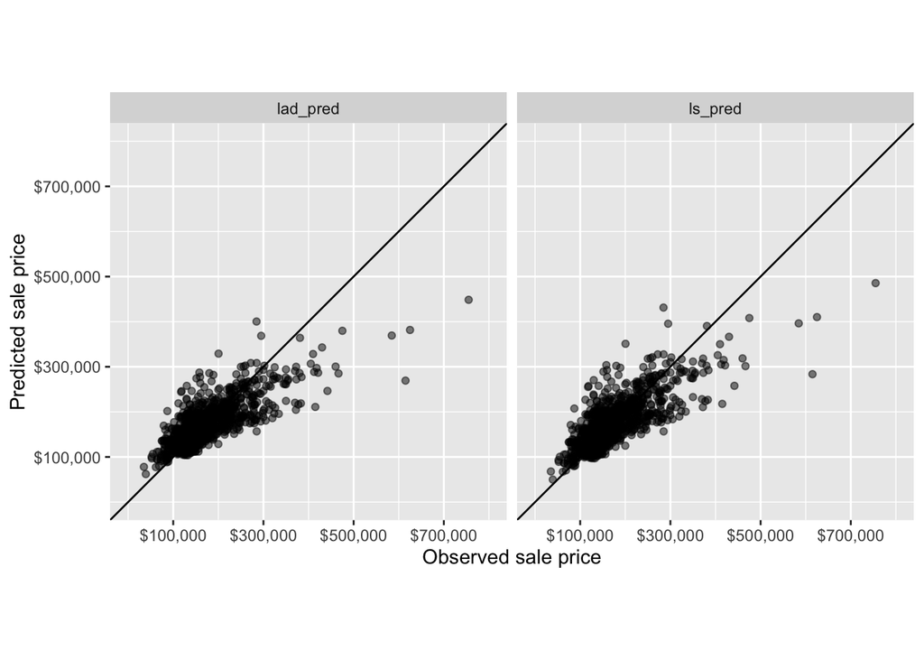

Figure 1: Scatterplots of the predicted and true sale price values for the LAD and LS algorithms for the training data

```r
pred_train_df |>
  pivot_longer(c("ls_pred", "lad_pred"),
               names_to = "algorithm",
               values_to = "pred") |>
  ggplot() +
  geom_point(aes(x = true, y = pred),
             alpha = 0.5) +
  geom_abline(intercept = 0, slope = 1) +
  scale_x_continuous(name = "Observed sale price",
                     breaks = 100000 * c(1, 3, 5, 7),
                     limits = c(0, 800000),
                     labels = paste0("$", c(1, 3, 5, 7), "00,000")) +
  scale_y_continuous(name = "Predicted sale price",
                     breaks = 100000 * c(1, 3, 5, 7),
                     limits = c(0, 800000),
                     labels = paste0("$", c(1, 3, 5, 7), "00,000")) +
  coord_equal() +
  facet_wrap(~algorithm)
```

### 1.5 PCS evaluation

#### Predictability (validation performance)

While the training performance is informative, if we want to get a sense of how well the algorithm would perform on future data we actually need to evaluate the algorithms on the validation set (which is chosen to be as similar as possible to the future data). Recall that we used a time-split to separate the dataset into training, validation and test sets.

Let’s repeat the analysis above, but this time for the validation set houses.

First we need to generate predictions for the validation set houses:

```r
pred_val_df <- tibble(true = ames_val_preprocessed$sale_price,
                      ls_pred = predict(ls_area, ames_val_preprocessed),
                      lad_pred = predict(lad_area, ames_val_preprocessed))
# look at the first 6 rows
head(pred_val_df)
```

```
# A tibble: 6 × 3
    true ls_pred lad_pred
   <int>   <dbl>    <dbl>
1 155000 169162.  167840.
2 178000 176491.  174341.
3 254750 252290.  241583.
4 230000 263665.  251674.
5 146500 179772.  177252.
6 124000 127161.  130580.
```

Then we can compute the performance measures for our validation set predictions:

```r
pred_val_df |>
  pivot_longer(c("ls_pred", "lad_pred"),
               names_to = "algorithm",
               values_to = "pred") |>
  group_by(algorithm) |>
  summarise(rmse = rmse_vec(truth = true, estimate = pred),
            mae = mae_vec(truth = true, estimate = pred),
            mad = median(abs(true - pred)),
            cor = cor(true, pred),
            rsq = rsq_vec(truth = true, estimate = pred))
```

```
# A tibble: 2 × 6
  algorithm   rmse    mae    mad   cor   rsq
  <chr>      <dbl>  <dbl>  <dbl> <dbl> <dbl>
1 lad_pred  49507. 34303. 22188. 0.696 0.485
2 ls_pred   49377. 34714. 24150. 0.696 0.485
```

Again, the performance for the two algorithms are very similar to one another, and again we see that the LS algorithm performs best in terms of the rMSE measure, but the LAD algorithm performs best in terms of the MAE and MAD measure (the two algorithms have identical performance in terms of the correlation and $R^2$ measures).

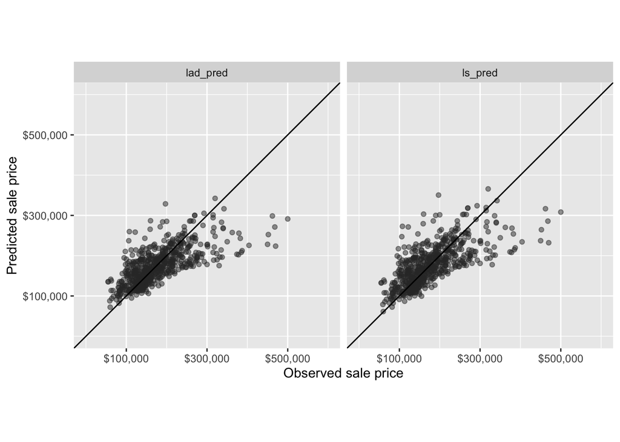

Figure 2: Scatterplots of the predicted and true sale price values for the LAD and LS algorithms applied to the validation data

```r
pred_val_df |>
  pivot_longer(c("ls_pred", "lad_pred"),
               names_to = "algorithm",
               values_to = "pred") |>
  ggplot() +
  geom_point(aes(x = true, y = pred), alpha = 0.5, col = "grey20") +
  geom_abline(intercept = 0, slope = 1) +
  scale_x_continuous(name = "Observed sale price",
                     #limits = c(50000, 650000),
                     breaks = 100000 * c(1, 3, 5),
                     limits = c(0, 600000),
                     labels = paste0("$", c(1, 3, 5), "00,000")) +
  scale_y_continuous(name = "Predicted sale price",
                     #limits = c(50000, 650000),
                     breaks = 100000 * c(1, 3, 5),
                     limits = c(0, 600000),
                     labels = paste0("$", c(1, 3, 5), "00,000")) +
  coord_equal() +
  facet_wrap(~algorithm)
```

#### Stability to data perturbations

To assess the stability of our data to appropriate perturbations in the data, we first need to decide what makes an “appropriate” perturbation. That is, what type of data perturbation (e.g., adding random noise, or performing sampling) most resembles the way that the data *could* have been measured or collected differently, as well as how these results will be applied in the future.

While the Ames housing data does not correspond to a random sample from a greater population of houses, each house is more-or-less exchangeable, meaning that a random sampling technique would be a reasonable perturbation, so we will draw 100 boostrap samples of the original data.

Moreover, it is plausible that the living area measurements involve a slight amount of measurement error, although we do not have a realistic sense of how much. To really stress-test our results, we choose to add another perturbation to the data that involves adding some random noise to 30% of the `gr_liv_area` measurements. Since the standard deviation of the living area is approximately 500, we decide to add or subtract a random number between 0 and 250 (i.e. add noise up to half a standard deviation) to 30% of `gr_liv_area` observations.

Since we will be repeating this analysis many times, we will write a function that will take an Ames dataset, and return a perturbed version of it.

```r
perturbAmes <- function(.ames_data,
                        .perturb_gr_liv_area = FALSE) {
  perturbed_ames <- .ames_data |>
    # create a binary variable that indicates which 30% of the area values to perturb
    mutate(perturb_area = rbernoulli(n(), p = 0.3) * .perturb_gr_liv_area) |>
    # conduct a bootstrap sample
    sample_frac(1, replace = TRUE) |>
    rowwise() |>
    # perturb the gr_liv_area variable
    mutate(gr_liv_area = if_else(perturb_area == 1 & .perturb_gr_liv_area,
                                 # add some number between -250 and 250
                                 gr_liv_area + as.integer(round(runif(1, -250, 250))),
                                 # or else, do not perturb the living area
                                 gr_liv_area)) |>
    # undo rowwise()
    ungroup() |>
    # remove unnecessary binary variable
    select(-perturb_area)
  return(perturbed_ames)
}
```

Below we create a tibble with a list column containing the 100 perturbed versions of the training data.

```r
set.seed(82634)
ames_data_perturbed <- tibble(iter = 1:100) |>
  rowwise() |>
  mutate(data_train_perturbed = list(perturbAmes(ames_train_preprocessed,
                                                 .perturb_gr_liv_area = TRUE))) |>
  ungroup()
ames_data_perturbed
```

```
# A tibble: 100 × 2
    iter data_train_perturbed
   <int> <list>
 1     1 <tibble [1,126 × 48]>
 2     2 <tibble [1,126 × 48]>
 3     3 <tibble [1,126 × 48]>
 4     4 <tibble [1,126 × 48]>
 5     5 <tibble [1,126 × 48]>
 6     6 <tibble [1,126 × 48]>
 7     7 <tibble [1,126 × 48]>
 8     8 <tibble [1,126 × 48]>
 9     9 <tibble [1,126 × 48]>
10    10 <tibble [1,126 × 48]>
# ℹ 90 more rows
```

Then we can define a tibble that has a list column containing each relevant LS and LAD model

```r
perturbed_fit_area <- ames_data_perturbed |>
  rowwise() |>
  mutate(ls = list(lm(sale_price ~ gr_liv_area, data_train_perturbed)),
         lad = list(lad(sale_price ~ gr_liv_area, data_train_perturbed))) |>
  ungroup()
perturbed_fit_area
```

```
# A tibble: 100 × 4
    iter data_train_perturbed  ls     lad
   <int> <list>                <list> <list>
 1     1 <tibble [1,126 × 48]> <lm>   <lad>
 2     2 <tibble [1,126 × 48]> <lm>   <lad>
 3     3 <tibble [1,126 × 48]> <lm>   <lad>
 4     4 <tibble [1,126 × 48]> <lm>   <lad>
 5     5 <tibble [1,126 × 48]> <lm>   <lad>
 6     6 <tibble [1,126 × 48]> <lm>   <lad>
 7     7 <tibble [1,126 × 48]> <lm>   <lad>
 8     8 <tibble [1,126 × 48]> <lm>   <lad>
 9     9 <tibble [1,126 × 48]> <lm>   <lad>
10    10 <tibble [1,126 × 48]> <lm>   <lad>
# ℹ 90 more rows
```

We can then generate sale price predictions for each house in the validation set using each perturbed LS and LAD fit.

```r
perturbed_fit_area_pred <- perturbed_fit_area |>
  rowwise() |>
  transmute(iter,
            true_val = list(ames_val_preprocessed$sale_price),
            pred_val_ls = list(predict(ls, ames_val_preprocessed)),
            pred_val_lad = list(predict(lad, ames_val_preprocessed))) |>
  ungroup()
perturbed_fit_area_pred
```

```
# A tibble: 100 × 4
    iter true_val    pred_val_ls pred_val_lad
   <int> <list>      <list>      <list>
 1     1 <int [636]> <dbl [636]> <dbl [636]>
 2     2 <int [636]> <dbl [636]> <dbl [636]>
 3     3 <int [636]> <dbl [636]> <dbl [636]>
 4     4 <int [636]> <dbl [636]> <dbl [636]>
 5     5 <int [636]> <dbl [636]> <dbl [636]>
 6     6 <int [636]> <dbl [636]> <dbl [636]>
 7     7 <int [636]> <dbl [636]> <dbl [636]>
 8     8 <int [636]> <dbl [636]> <dbl [636]>
 9     9 <int [636]> <dbl [636]> <dbl [636]>
10    10 <int [636]> <dbl [636]> <dbl [636]>
# ℹ 90 more rows
```

```r
perturbed_fit_area_pred_performance <- perturbed_fit_area_pred |>
  pivot_longer(c("pred_val_ls", "pred_val_lad"),
               names_to = "fit",
               values_to = "pred_val") |>
  group_by(iter, fit) |>
  rowwise() |>
  mutate(rMSE = rmse_vec(true_val, pred_val),
         MAE = mae_vec(true_val, pred_val),
         MAD = median(abs(true_val - pred_val)),
         cor = cor(true_val, pred_val))
perturbed_fit_area_pred_performance
```

```
# A tibble: 200 × 8
# Rowwise:  iter, fit
    iter true_val    fit          pred_val      rMSE    MAE    MAD   cor
   <int> <list>      <chr>        <list>       <dbl>  <dbl>  <dbl> <dbl>
 1     1 <int [636]> pred_val_ls  <dbl [636]> 49394. 34353. 22617. 0.696
 2     1 <int [636]> pred_val_lad <dbl [636]> 49608. 34292. 22176. 0.696
 3     2 <int [636]> pred_val_ls  <dbl [636]> 49478. 34331. 22836. 0.696
 4     2 <int [636]> pred_val_lad <dbl [636]> 49905. 34303. 22381. 0.696
 5     3 <int [636]> pred_val_ls  <dbl [636]> 49337. 34451. 23203. 0.696
 6     3 <int [636]> pred_val_lad <dbl [636]> 49790. 34297. 22402. 0.696
 7     4 <int [636]> pred_val_ls  <dbl [636]> 49334. 34454. 23214. 0.696
 8     4 <int [636]> pred_val_lad <dbl [636]> 49679. 34280. 22041. 0.696
 9     5 <int [636]> pred_val_ls  <dbl [636]> 49393. 34610. 23702. 0.696
10     5 <int [636]> pred_val_lad <dbl [636]> 49603. 34303. 22465. 0.696
# ℹ 190 more rows
```

Then we can visualize the distribution of the performance metrics across the 100 perturbed iterations:

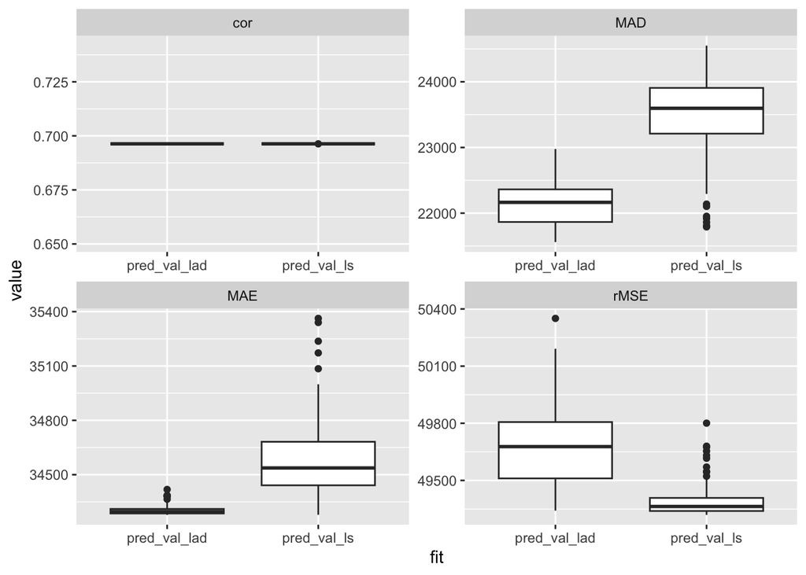

```r
perturbed_fit_area_pred_performance |>
  pivot_longer(c("rMSE", "MAE", "MAD", "cor"),
               names_to = "metric",
               values_to = "value") |>
  ggplot() +
  geom_boxplot(aes(x = fit, y = value)) +
  facet_wrap(~metric, scales = "free", ncol = 2)
```

Overall (by realizing that the range of each y-axis is fairly narrow), it seems like both algorithms are fairly stable in terms of these performance metrics.

```r
# compute the interval (max and min prediction) for each validation house
predStabilityPlot <- function(.perturbed_pred_df,
                              .true_var,
                              .pred_var,
                              .title = NULL) {

  perturbed_pred_interval <- .perturbed_pred_df |>
    pivot_longer({{ .pred_var }},
                 names_to = "fit", values_to = "pred") |>
    group_by(pid, fit) |>
    # compute the range (interval) of predictions for each response
    summarise(true = unique({{ .true_var }}),
              min_pred = min(pred),
              max_pred = max(pred)) |>
    ungroup()

  perturbed_pred_interval |>
    # plot the intervals
    ggplot() +
    geom_abline(intercept = 0, slope = 1, alpha = 0.5) +
    geom_segment(aes(y = true, yend = true, x = min_pred, xend = max_pred),
                 alpha = 0.5) +
    scale_y_continuous(name = "Observed sale response", labels = label_dollar()) +
    scale_x_continuous(name = "Predicted sale response range", labels = label_dollar())  +
    ggtitle(.title)
}
```

Then we can produce the prediction stability plots for LS and LAD as follows

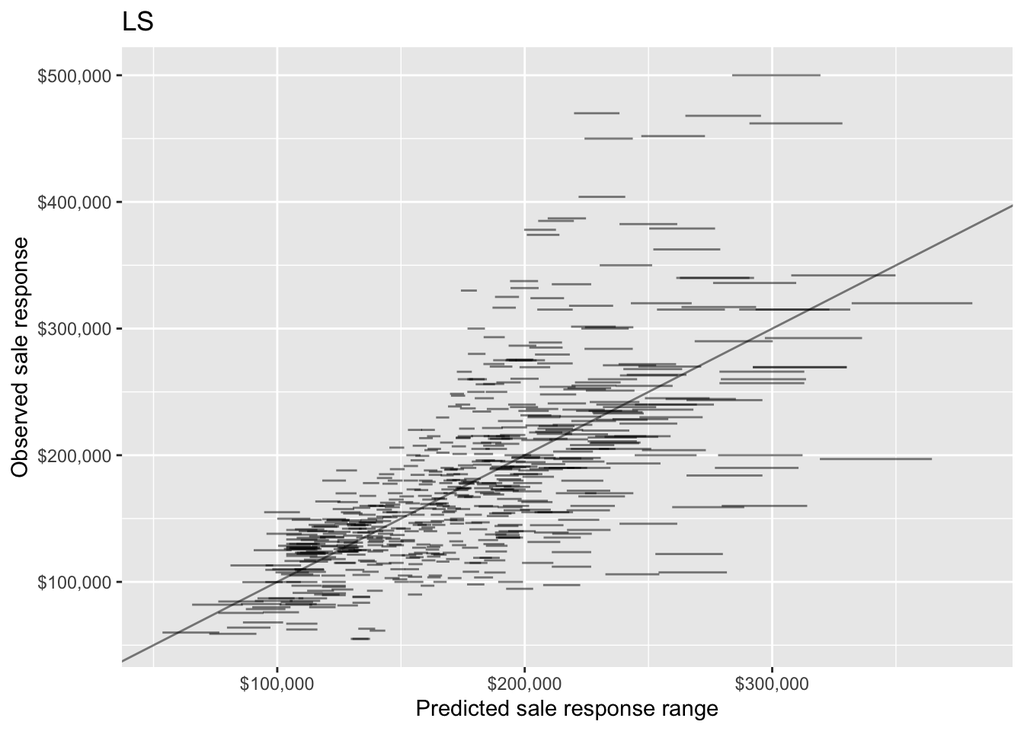

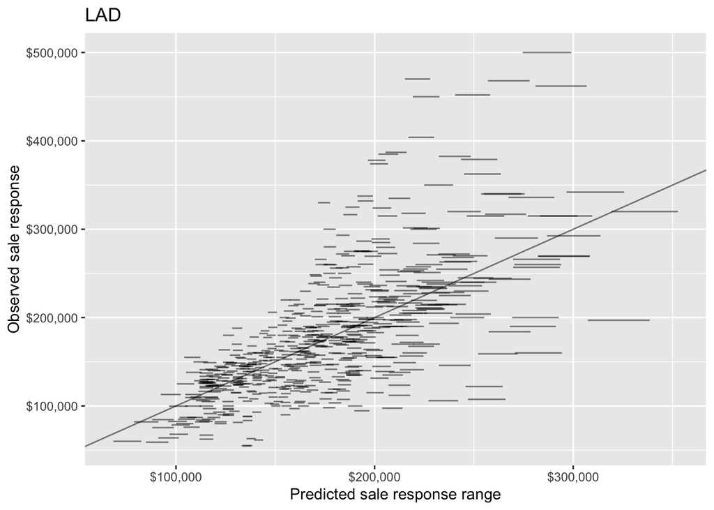

```r
perturbed_fit_area_pred |>
  select(true_val, pred_val_ls) |>
  rowwise() |>
  # add a house identifier (pid) column
  mutate(pid = list(ames_val_preprocessed$pid)) |>
  # expand the nested tibble into a regular tibble
  unnest(cols = c(true_val, pred_val_ls, pid)) |>
  # create the prediction stability plot
  predStabilityPlot(.true_var = true_val,
                    .pred_var = pred_val_ls,
                    .title = "LS")
perturbed_fit_area_pred |>
  select(true_val, pred_val_lad) |>
  rowwise() |>
  # add a house identifier (pid) column
  mutate(pid = list(ames_val_preprocessed$pid)) |>
  # expand the nested tibble into a regular tibble
  unnest(cols = c(true_val, pred_val_lad, pid)) |>
  # create the prediction stability plot
  predStabilityPlot(.true_var = true_val,
                    .pred_var = pred_val_lad,
                    .title = "LAD")
```

It seems like the range of predicted responses for each house is fairly narrow (i.e., the predictions are fairly stable), especially for houses in the middle of the price range, but is slightly wider (i.e., the predictions are somewhat less stable) for houses with higher predicted sale prices.